# Tækniskýrsla - HoFT

Brynjar Ari, Einar Geir, Halldór Andri og Jakob Stefán

2025-04-02

## **Úrdráttur**

Í þessari tilraun voru áhrif ýmissa þátta á sviftíma ($Y_1$) og lendingarnákvæmni ($Y_2$) bréfaþyrla könnuð með $2^5$ þáttatilraun. Fimm þættir voru valdir: breidd þyrlunnar, lengd þyrlunnar, vængjalengd, notkun bréfaklemmu og límband á vængjum. Mæld var svörun sviftíma (sek.) og láréttrar lendingarfjarlægðar (cm) frá upphafspunkti eftir sleppingu úr 3,88 m hæð.

Gagnaúrvinnsla fór fram með Yates-algrími og staðfest með normal probability plots og ANOVA-greiningum. Niðurstöður sýndu að einungis vængjalengd (C) hafði marktæk áhrif á sviftíma ($Y_1$). Lengri vængir skiluðu marktækt lengri sviftíma.

Lokaaðhvarfslíkön eru eftirfarandi:

**Sviftími:**
$$Y_1 = 2.871 +
0.750 \cdot C$$

## **Inngangur**

Hönnun bréfaþyrla er áhugavert dæmi um hvernig beita má aðferðum tilraunahönnunar og tölfræðigreiningar til að bæta lofttæknilega eiginleika einfaldra smíða. Þessi skýrsla fjallar um tilraun þar sem markmiðið var að greina hvaða þættir hafa marktæk áhrif á tvo mikilvæga eiginleika bréfaþyrla: sviftíma (tímann sem tekur þyrluna að svífa niður) og lendingarnákvæmni (lárétta fjarlægð frá upphafspunkti).

Viðfangsefni verkefnisins var að kanna áhrif fimm lykilþátta með því að framkvæma $2^5$ þáttatilraun. Þættirnir sem skoðaðir voru eru breidd þyrlu, lengd þyrlu, vængjalengd, notkun bréfaklemmu og notkun límbands. Mælingar fóru fram í stöðluðu umhverfi með það fyrir augum að finna hvaða breytur hafa mest áhrif og hvort einhverjir þættir vinna saman (víxlhrif).

Tilgangur verkefnisins er tvíþættur: Í fyrsta lagi að öðlast betri skilning á því hvernig tilraunahönnun og tölfræðigreining hjálpa til við að greina áhrifavalda, og í öðru lagi að nýta þá þekkingu til að hanna þyrlur með betri eiginleika. Verkefnið getur því bæði nýst sem hagnýt leiðbeining fyrir framtíðarhönnun og sem dæmi um aðferðarfræði í tæknilegum rannsóknum.

## **Áhrifavaldar og val á þáttum**

### **Umræður um mögulega þætti**

Eftirfarandi þættir geta haft áhrif á sviftíma og lendingarnákvæmni bréfaþyrla: - Breidd þyrlunnar - Lengd þyrlunnar - Vængjalengd - Notkun bréfaklemmu - Límband á vængjum - Þyngd pappírsins - Symmetría vængja - Fellingar á vængjum - Raka- og lofthitastig - Snúningshraði við sleppingu

### **Endanlegt val á þáttum fyrir $2^k$ tilraun**

Fimm þættir voru valdir fyrir $2^5$ tilraun ($k = 5$):

| **Breyta** | **Lág gildi (–)** | **Hátt gildi (+)** | **Rökstuðningur** | **Áhrifaþættir** |
| --- | --- | --- | --- | --- |
| **Breidd** | 3 cm | 5 cm | Hefur áhrif á lofthitadreifingu | a |
| **Lengd** | 8 cm | 13 cm | Áhrif á massadreifingu og stabilitet | b |
| **Vængjalengd** | 8 cm | 13 cm | Hefur áhrif á lyftikraft | c |
| **Bréfaklemma** | Nei | Já | Bætir við massa og tilfærir þyngdarpunkt | d |
| **Límband** | Nei | Já | Breytir yfirborðsviðnámi og vængstyrk | e |

*Tafla 1: Val á áhrifaþáttum*

Fjöldi mælinga $n = 1$ endurtekningar á hverja samsetningu.

### **Aðferð til að lágmarka pappírsnotkun**

Búnar voru til 8 þyrlur – ein fyrir hverja samsetningu af breidd (2 gildi), lengd (2 gildi) og vængjalengd (2 gildi). Þannig voru allir 2×2×2 = 8 möguleikar prófaðir fyrir þyrlulögun.

Hver þyrla var notuð í 4 prófanir:

- Með/án bréfaklemmu
- Með/án límbands

Þannig nýttist hver þyrla í 4 tilraunakeyrslur og dregið var úr pappírsnotkun.

## **Framkvæmd tilraunarinnar**

### **Efni og aðstæður**

- Sleppihæð: 3,88m (Uppi í stiga á 3.hæð í VR-3)
- Notaður pappír: A4, $80 \frac{g}{m^2}$
- Þyrlur voru hannaðar og merktar eftir samsetningum breytanna.

[figure not shown]

*Mynd 1: Þyrlur*

### **Tilraunaferli**

Þyrlunum var sleppt efst í tröppunum þar sem einstaklingur stóð með hendina lárétt fyrir framan sig. Beint fyrir neðan þyrluna hafði verið merktur punktur sem notaður var til þess að mæla lendingarfjarlægð frá upphafspúnkti. Maðurinn telur niður og sleppir þyrlunni. Á sama tíma var tími settur af stað í síma og stoppaður um leið og þyrlan lendir í gólfinu. Lengd frá upphafspunkti var mæld með mæliforriti í síma.

### **Mælibreytur**

- **Sviftími ($Y_1$)**: mældur í sekúntum með skeiðklukkur í síma
- **Lárétt fjarlægð ($Y_2$)**: mældur í cm með fæliforriti í síma

### **Óvissu þættir**

**Stýranlegir**:

- Sleppihæð og horn við sleppingu
- Hönnun og samsetning þyrlna
- Tímasetning mælinga (t.d. tíminn sem líður frá því að tíminn er ræstur þar til honum er lokið)
- Mæliforrit og virkni þess í snjallsíma

**Óstýranlegir**:

- Loftstreymi í herbergi
- Smávægilegar breytingar í pappírssniði
- Snúningshraði við sleppingu

## **Gagnaúrvinnsla og tölfræðileg greining**

### **Gagnasöfnun**

Sett var upp tafla í google sheets (Sjá töflu 2). Hún var sett upp þannig að hægt væri að taka mælingar fyrir hverja þyrlu og áhrifaþáttum bætt við hana.

|  |  | **(1)** |  | **d** |  | **e** |  | **de** |  |
| --- | --- | --- | --- | --- | --- | --- | --- | --- | --- |
| **Þyrla** | **Þættir** | **Y1** | **Y2** | **Y1** | **Y2** | **Y1** | **Y2** | **Y1** | **Y2** |
| **1** | **(1)** | 3.1 | 21 | 2.95 | 11 | 3.21 | 30 | 2.76 | 6 |
| **2** | **a** | 2.68 | 11 | 3.26 | 8 | 3.05 | 86 | 2.9 | 7 |
| **3** | **b** | 3.13 | 60 | 2.65 | 4 | 2.71 | 125 | 2.43 | 2 |
| **4** | **ab** | 2.51 | 31 | 2.96 | 4 | 3.08 | 61 | 2.55 | 0 |
| **5** | **c** | 4.3 | 37 | 3.83 | 21 | 2.96 | 0 | 3.95 | 21 |
| **6** | **ac** | 3.73 | 24 | 4.08 | 7 | 3.01 | 41 | 3.89 | 17 |
| **7** | **bc** | 3.33 | 10 | 3.03 | 8 | 3.51 | 37 | 3.45 | 10 |
| **8** | **abc** | 4.16 | 30 | 3.88 | 6 | 3.48 | 59 | 3.33 | 25 |

*Tafla 2: Gagnasöfnun*

## **Notkun Yates-algrímsins**

Gögnin voru síðan setta í tvær mismunandi töflur fyrir $Y_1$ og $Y_2$. Við notuðum Yates algrímið til þess að reikna `contasta` áhrifaþáttanna og þannig reikna `SS (sum og squares)` og `Áhrif` (Sjá á töflur 3 og 4).

| **Þættir** | **Y1_1** | **1** | **2** | **3** | **4** | **5** | **SS** | **Áhrif** |
| --- | --- | --- | --- | --- | --- | --- | --- | --- |
| (1) | 3.1 | 5.78 | 11.42 | 26.94 | 53.58 | 103.85 |  |  |
| a | 2.68 | 5.64 | 15.52 | 26.64 | 50.27 | 1.25 | 0.05 | 0.08 |
| b | 3.13 | 8.03 | 11.82 | 25.01 | 0.94 | -3.47 | 0.38 | -0.22 |
| ab | 2.51 | 7.49 | 14.82 | 25.26 | 0.31 | 2.17 | 0.15 | 0.14 |
| c | 4.3 | 6.21 | 12.05 | -0.78 | -2.28 | 11.99 | 4.49 | 0.75 |
| ac | 3.73 | 5.61 | 12.96 | 1.72 | -1.19 | 1.15 | 0.04 | 0.07 |
| bc | 3.33 | 7.91 | 10.64 | 0.23 | 1.8 | 0.31 | 0.00 | 0.02 |
| abc | 4.16 | 6.91 | 14.62 | 0.08 | 0.37 | 1.55 | 0.08 | 0.10 |
| d | 2.95 | 6.26 | -1.04 | -0.68 | 7.1 | -0.05 | 0.00 | 0.00 |
| ad | 3.26 | 5.79 | 0.26 | -1.6 | 4.89 | 2.35 | 0.17 | 0.15 |
| bd | 2.65 | 5.97 | 0.62 | 0.55 | 1.78 | -3.21 | 0.32 | -0.20 |
| abd | 2.96 | 6.99 | 1.1 | -1.74 | -0.63 | -1.13 | 0.04 | -0.07 |
| dc | 3.83 | 5.66 | 0.21 | 1.2 | -0.8 | 1.97 | 0.12 | 0.12 |
| acd | 4.08 | 4.98 | 0.02 | 0.6 | 1.11 | -1.07 | 0.04 | -0.07 |
| bcd | 3.03 | 7.84 | 0.26 | 0.45 | 2.2 | -1.87 | 0.11 | -0.12 |
| abcd | 3.88 | 6.78 | -0.18 | -0.08 | -0.65 | -0.43 | 0.01 | -0.03 |
| e | 3.21 | -0.42 | -0.14 | 4.1 | -0.3 | -3.31 | 0.34 | -0.21 |
| ae | 3.05 | -0.62 | -0.54 | 3 | 0.25 | -0.63 | 0.01 | -0.04 |
| be | 2.71 | -0.57 | -0.6 | 0.91 | 2.5 | 1.09 | 0.04 | 0.07 |
| abe | 3.08 | 0.83 | -1 | 3.98 | -0.15 | -1.43 | 0.06 | -0.09 |
| ce | 2.96 | 0.31 | -0.47 | 1.3 | -0.92 | -2.21 | 0.15 | -0.14 |
| ace | 3.01 | 0.31 | 1.02 | 0.48 | -2.29 | -2.41 | 0.18 | -0.15 |
| bce | 3.51 | 0.25 | -0.68 | -0.19 | -0.6 | 1.91 | 0.11 | 0.12 |
| abce | 3.48 | 0.85 | -1.06 | -0.44 | -0.53 | -2.85 | 0.25 | -0.18 |
| de | 2.76 | -0.16 | -0.2 | -0.4 | -1.1 | 0.55 | 0.01 | 0.03 |
| ade | 2.9 | 0.37 | 1.4 | -0.4 | 3.07 | -2.65 | 0.22 | -0.17 |
| bde | 2.43 | 0.05 | 0 | 1.49 | -0.82 | -1.37 | 0.06 | -0.09 |
| abde | 2.55 | -0.03 | 0.6 | -0.38 | -0.25 | 0.07 | 0.00 | 0.00 |
| cde | 3.95 | 0.14 | 0.53 | 1.6 | 0 | 4.17 | 0.54 | 0.26 |
| acde | 3.89 | 0.12 | -0.08 | 0.6 | -1.87 | 0.57 | 0.01 | 0.04 |
| bcde | 3.45 | -0.06 | -0.02 | -0.61 | -1 | -1.87 | 0.11 | -0.12 |
| abcde | 3.33 | -0.12 | -0.06 | -0.04 | 0.57 | 1.57 | 0.08 | 0.10 |

*Tafla 3: Yates algrím fyrir $Y_1$*

| **Þættir** | **Y2_1** | **1** | **2** | **3** | **4** | **5** | **áhrif** | **SS** |
| --- | --- | --- | --- | --- | --- | --- | --- | --- |
| (1) | 21 | 32 | 123 | 224 | 293 | 820 |  |  |
| a | 11 | 91 | 101 | 69 | 527 | 14 | 0.88 | 6.1 |
| b | 60 | 61 | 27 | 439 | -51 | 124 | 7.75 | 480.5 |
| ab | 31 | 40 | 42 | 88 | 65 | -94 | -5.88 | 276.1 |
| c | 37 | 19 | 302 | -32 | 13 | -114 | -7.13 | 406.1 |
| ac | 24 | 8 | 137 | -19 | 111 | 116 | 7.25 | 420.5 |
| bc | 10 | 28 | 15 | 55 | 29 | -90 | -5.63 | 253.1 |
| abc | 30 | 14 | 73 | 10 | -123 | 184 | 11.50 | 1058.0 |
| d | 11 | 116 | -39 | 38 | -7 | -506 | -31.63 | 8001.1 |
| ad | 8 | 186 | 7 | -25 | -107 | -32 | -2.00 | 32.0 |
| bd | 4 | 41 | -3 | 125 | 33 | -202 | -12.63 | 1275.1 |
| abd | 4 | 96 | -16 | -14 | 83 | 156 | 9.75 | 760.5 |
| dc | 21 | 13 | -8 | 14 | -83 | 260 | 16.25 | 2112.5 |
| acd | 7 | 2 | 63 | 15 | -7 | -118 | -7.38 | 435.1 |
| bcd | 8 | 38 | -1 | -139 | 61 | 100 | 6.25 | 312.5 |
| abcd | 6 | 35 | 11 | 16 | 123 | -122 | -7.63 | 465.1 |
| e | 30 | -10 | 59 | -22 | -155 | 234 | 14.63 | 1711.1 |
| ae | 86 | -29 | -21 | 15 | -351 | 116 | 7.25 | 420.5 |
| be | 125 | -13 | -11 | -165 | 13 | 98 | 6.13 | 300.1 |
| abe | 61 | 20 | -14 | 58 | -45 | -152 | -9.50 | 722.0 |
| ce | 0 | -3 | 70 | 46 | -63 | -100 | -6.25 | 312.5 |
| ace | 41 | 0 | 55 | -13 | -139 | 50 | 3.13 | 78.1 |
| bce | 37 | -14 | -11 | 71 | 1 | 76 | 4.75 | 180.5 |
| abce | 59 | -2 | -3 | 12 | 155 | 62 | 3.88 | 120.1 |
| de | 6 | 56 | -19 | -80 | 37 | -196 | -12.25 | 1200.5 |
| ade | 7 | -64 | 33 | -3 | 223 | -58 | -3.63 | 105.1 |
| bde | 2 | 41 | 3 | -15 | -59 | -76 | -4.75 | 180.5 |
| abde | 0 | 22 | 12 | 8 | -59 | 154 | 9.63 | 741.1 |
| cde | 21 | 1 | -120 | 52 | 77 | 186 | 11.63 | 1081.1 |
| acde | 17 | -2 | -19 | 9 | 23 | 0 | 0.00 | 0.0 |
| bcde | 10 | -4 | -3 | 101 | -43 | -54 | -3.38 | 91.1 |
| abcde | 25 | 15 | 19 | 22 | -79 | -36 | -2.25 | 40.5 |

*Tafla 4: Yates algrím fyrir $Y_2$*

### **Normal probability plot**

Normal probability plot var notað til að greina hvaða þættir höfðu marktæk áhrif með því að skoða hversu mikið þeir skáru sig úr heildarmynstrinu.

Hér má sjá Normal probabiliry plot fyrir áhrif $Y_1$

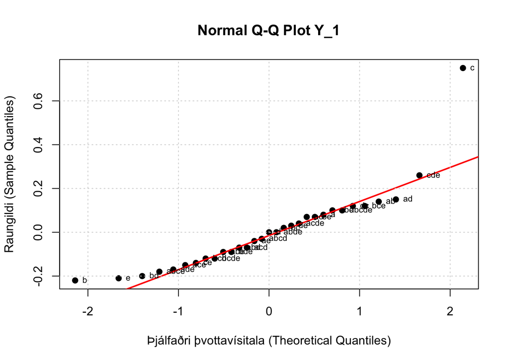

```r
# Gögnin þín fyrir Y1
values <- c(0.08, -0.22, 0.14, 0.75, 0.07, 0.02, 0.10, 0.00, 0.15, -0.20,
            -0.07, 0.12, -0.07, -0.12, -0.03, -0.21, -0.04, 0.07, -0.09, -0.14,
            -0.15, 0.12, -0.18, 0.03, -0.17, -0.09, 0.00, 0.26, 0.04, -0.12, 0.10)

labels <- c("a", "b", "ab", "c", "ac", "bc", "abc", "d", "ad", "bd", "abd", "dc",
            "acd", "bcd", "abcd", "e", "ae", "be", "abe", "ce", "ace", "bce", "abce",
            "de", "ade", "bde", "abde", "cde", "acde", "bcde", "abcde")

# Búa til Q-Q plot og fá punktana til að skila sér staðsetningum
qq <- qqnorm(values,
             main = "Normal Q-Q Plot Y_1",
             xlab = "Þjálfaðri þvottavísitala (Theoretical Quantiles)",
             ylab = "Raungildi (Sample Quantiles)",
             pch = 19)  # pch 19 fyrir punkta

qqline(values, col = "red", lwd = 2)
grid()

# Merkjum punktana með texta - notum pos = 4 til að setja textann til hægri við punkta
text(qq$x, qq$y, labels = labels, pos = 4, cex = 0.7)
```

Hér sést að að tvær þærrit skera sig greinileg frá mynstirnu en það eru þættir $B$ og $C$. Einnig er hægt að sjá að þættir $E$ og víxlverkun $AD$ skera sig aðeins út. Þessir þættir verða skoðaðir betur í ANOVA greiningu.

Næst sjáum við Normal probabiliry plot fyrir áhrif $Y_2$

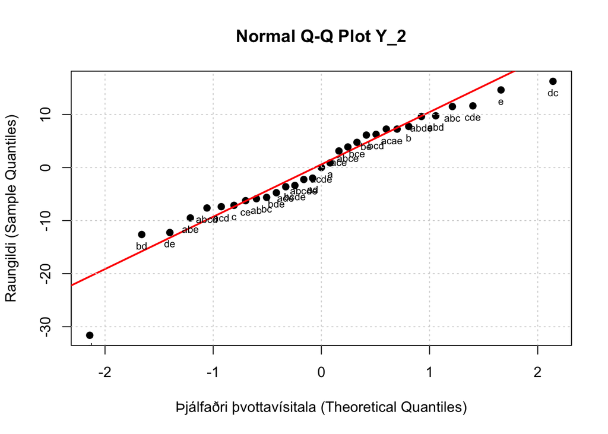

```r
# Gögnin þín fyrir Y2
values <- c(0.875, 7.75, -5.875, -7.125, 7.25, -5.625, 11.5, -31.625, -2, -12.625,
            9.75, 16.25, -7.375, 6.25, -7.625, 14.625, 7.25, 6.125, -9.5, -6.25,
            3.125, 4.75, 3.875, -12.25, -3.625, -4.75, 9.625, 11.625, 0, -3.375, -2.25)

labels <- c("a", "b", "ab", "c", "ac", "bc", "abc", "d", "ad", "bd", "abd", "dc",
            "acd", "bcd", "abcd", "e", "ae", "be", "abe", "ce", "ace", "bce", "abce",
            "de", "ade", "bde", "abde", "cde", "acde", "bcde", "abcde")

# Búa til Q-Q plot og fá punktanna hnit
qq <- qqnorm(values,
             main = "Normal Q-Q Plot Y_2",
             xlab = "Þjálfaðri þvottavísitala (Theoretical Quantiles)",
             ylab = "Raungildi (Sample Quantiles)",
             pch = 19)  # pch 19 fyrir fallega punkta

qqline(values, col = "red", lwd = 2)
grid()

# Merkjum punktana með labels úr breytunni 'labels'
text(qq$x, qq$y, labels = labels, pos = 1, cex = 0.7)
```

Hér eru einnig tvær þættir sem skera sig greinilega út en það eru $D$ og $DC$. Einnig er hægt að sjá að víxlverkanir $BD$, $CDE$ og þáttur $E$ sker sig aðeins út. Þessir þættir verað skoðaðir betur í ANOVA greiningu.

### **Anova-greining**

Nú munum við skoða þættina en betur og athuga marktækni þeirra

### **Anova Y_1**

```r
# 4. ANOVA-greining fyrir Y_1 með þáttum b og c:
model_Y1 <- aov(Y_1 ~ b + c_var +  a*d + e, data = df)
summary(model_Y1)
```

```
##             Df Sum Sq Mean Sq F value   Pr(>F)
## b            1  0.376   0.376   3.429   0.0759 .
## c_var        1  4.493   4.493  40.937 1.07e-06 ***
## a            1  0.049   0.049   0.445   0.5109
## d            1  0.000   0.000   0.001   0.9789
## e            1  0.342   0.342   3.120   0.0896 .
## a:d          1  0.173   0.173   1.573   0.2214
## Residuals   25  2.744   0.110
## ---
## Signif. codes:  0 '***' 0.001 '**' 0.01 '*' 0.05 '.' 0.1 ' ' 1
```

Áhrifa þáttur $C$ eini þáttur sem að er nægilega marktækur (miða við $\alpha = 0.05$)

### **Anova Y_2**

```r
# 5. ANOVA-greining fyrir Y_2 með þáttum d og c:
model_Y2 <- aov(Y_2 ~ d + c_var*d + b*d + e + c_var*d*e , data = df)
summary(model_Y2)
```

```
##             Df Sum Sq Mean Sq F value   Pr(>F)
## d            1   8001    8001  25.150 5.08e-05 ***
## c_var        1    406     406   1.277   0.2707
## b            1    481     481   1.510   0.2321
## e            1   1711    1711   5.379   0.0301 *
## d:c_var      1   2112    2112   6.640   0.0172 *
## d:b          1   1275    1275   4.008   0.0578 .
## c_var:e      1    313     313   0.982   0.3324
## d:e          1   1201    1201   3.774   0.0650 .
## d:c_var:e    1   1081    1081   3.398   0.0788 .
## Residuals   22   6999     318
## ---
## Signif. codes:  0 '***' 0.001 '**' 0.01 '*' 0.05 '.' 0.1 ' ' 1
```

Áhrifa þættir $D$, $E$ og víxlverkun $DC$ sýna nægilega marktækni.

## **Aðhvarfsgreining og líkön**

### **Líkan fyrir sviftíma ($Y_1$)**

Fyrir $Y_1$ er aðeins þáttur $C$ marktækur. Aðhvarfslíkanið verðu því:

$$Y_1 = \beta_0 + \beta_C \cdot C +
\epsilon$$

R leggur mat á stuðla aðhvarfslíkanisinnsi:

```r
model_Y1 <- aov(Y_1 ~ c_var, data = df)
coef(model_Y1)
```

```
## (Intercept)       c_var
##    2.870625    0.749375
```

Full búið mat á sviftíma ($Y_1$) er þá:

$$Y_1 = 2.871 + 0.750 \cdot C$$

### **Líkan fyrir lendingarnákvæmni ($Y_2$)**

Fyrir $Y_1$ eru þættir $D$. $E$ og víxlvlverkun $DC$ marktækt. Aðhvarfslíkanið verður því:

$$Y_2 = \gamma_0 + \gamma_D \cdot D +
\gamma_E \cdot E + \gamma_{DC} \cdot (DC) + \epsilon$$
R leggur mat á stuðla aðhvarfslíkanisinnsi:

```r
model_Y1 <- aov(Y_2 ~ d + e + d*c_var, data = df)
coef(model_Y1)
```

```
## (Intercept)           d           e       c_var     d:c_var
##     45.8125    -47.8750     14.6250    -23.3750     32.5000
```

Til að varpa betra ljósi á þessi víxlhrif var teiknað svokallað interaction plot, þar sem meðaltal $Y_2$ er sett fram fyrir hverja samsetningu af gildum þátta $C$ (vængjalengd) og $D$ (bréfaklemma).

Á myndinni hér að neðan má sjá hvernig áhrif þáttarins $D$ er háð því hvaða gildi $C$ tekur:

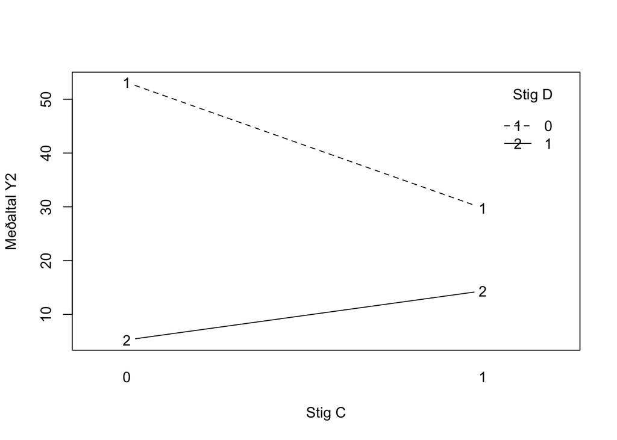

```r
interaction.plot(x.factor = df$c_var,          # x-ásinn táknar stig C
                 trace.factor = df$d,      # línurnar tákna mismunandi stigin af D
                 response = df$Y_2,         # svarbreytan sem er mæld
                 fun = mean,               # reiknar meðaltal fyrir hvern samsettan punkt
                 type = "b",               # bæði punkta- og línurit
                 legend = TRUE,            # bætir við skýringarlegu
                 xlab = "Stig C",          # titill á x-ás
                 ylab = "Meðaltal Y2",       # titill á y-ás
                 trace.label = "Stig D")   # titill fyrir línuskrá
```

## **Niðiurstöður**

Tilraunin leiddi í ljós eftirfarandi lykilatriði varðandi áhrif mismunandi þátta á sviftíma ($Y_1$) og lendingarnákvæmni ($Y_2$):

### **Sviftími ($Y_1$)**

Helsti áhrifaþáttur fyrir sviftíma reyndist vera vængjalengd (C). Aðrir þættir höfðu lítil sem engin marktæk áhrif þegar tekið var mið af tölfræðiprófunum.

Lengri vængjalengd (13 cm) skilaði marktækt lengri sviftíma samanborið við styttri vængi (8 cm). Þetta er líklega vegna aukins lyftikrafts sem lengri vængir skapa.

Endanlegt aðhvarfslíkan fyrir sviftíma er því:

$$Y_1 = 2.871 + 0.750 \cdot C$$

Það þýðir að með því að velja lengri vængjalengd má auka meðal sviftíma þyrlunnar um allt að 0,75 sekúndur.

## **Ályktanir**

Með því að nýta þessar niðurstöður er hægt að hanna bréfaþyrlu með aukinn sviftíma (lengri vængir) eða nákvæmari lendingu (styttri vængir með bréfaklemmu án límbands), allt eftir því hvaða eiginleiki er mikilvægari fyrir tiltekinn tilgang.

Ef markmiðið er að sameina kosti beggja þátta, þá væri skynsamlegt að hanna þyrlu með löngum vængjum fyrir lengri sviftíma og bæta við bréfaklemmu til að auka nákvæmni við lendingu.

Þessar upplýsingar eru gagnlegar til áframhaldandi hönnunar og prófunar bréfaþyrla eða annarra svipaðra smíða, þar sem áherslan liggur á lofttæknilegum eiginleikum og stöðugleika.

## **Viðauki**

### 1. **Gagnavinnsla**

```r
# 1. Skilgreinum hvaða samsetningar (treatment combinations) eru í gangi:
combinations <- c(
  "(1)","a","b","ab","c","ac","bc","abc",
  "d","ad","bd","abd","dc","acd","bcd","abcd",
  "e","ae","be","abe","ce","ace","bce","abce",
  "de","ade","bde","abde","cde","acde","bcde","abcde"
)

# 2. Skilgreinum svörun Y_1 í sömu röð:
Y_1 <- c(
  3.1, 2.68, 3.13, 2.51, 4.3, 3.73, 3.33, 4.16,
  2.95, 3.26, 2.65, 2.96, 3.83, 4.08, 3.03, 3.88,
  3.21, 3.05, 2.71, 3.08, 2.96, 3.01, 3.51, 3.48,
  2.76, 2.90, 2.43, 2.55, 3.95, 3.89, 3.45, 3.33
)

# 3. Skilgreinum svörun Y_2 í sömu röð:
Y_2 <- c(
  21, 11, 60, 31, 37, 24, 10, 30,
  11,  8,  4,  4, 21,  7,  8,  6,
  30, 86,125, 61,  0, 41, 37, 59,
   6,  7,  2,  0, 21, 17, 10, 25
)

# 4. Búum til dálka fyrir hvern þátt a, b, c, d, e sem 0/1-breytur.
#    Við athugum hvort samsetningin innihaldi stafinn 'a', 'b', 'c', 'd', eða 'e':
a_fac <- as.numeric(grepl("a", combinations))
b_fac <- as.numeric(grepl("b", combinations))
c_fac <- as.numeric(grepl("c", combinations))
d_fac <- as.numeric(grepl("d", combinations))
e_fac <- as.numeric(grepl("e", combinations))

# 5. Búum til lokagögnin sem data.frame:
df <- data.frame(
  combination = combinations,
  a = a_fac,
  b = b_fac,
  c_var = c_fac,
  d = d_fac,
  e = e_fac,
  Y_1 = Y_1,
  Y_2 = Y_2
)
```